# Practicum-3.2

Harsh

26/07/2020

```r
#Importing Libraries
library(fpc)
library(arules)
#unloadNamespace("arules")
#update.packages("arules")
#library(arules)
```

1. Download the data set Plant Disease Data Set. Note that the data file does not contain header names; you may wish to add those. The description of each column can be found in the data set explanation. This assignment must be completed within a separate R Markdown Notebook. Use read.transaction() from the arules package to read the data.
2. Explore the data set as you see fit and that allows you to get a sense of the data and get comfortable with it. Is there distributional skew in any of the features? Is there a need to apply a transform?
- I used read.transactions function to import the plants transaction data
- Since this the data is transaction i.e sparse matrix we cannot observe the skewness or distribution of the data
- Using summary and inspect I did explanatory analysis

```r
#Importing Dataset
plant_data <- read.transactions("C:\\Users\\harsh\\Desktop\\Introduction to Machine learning and Data Mining\\Practicum-3\\plants.data",sep = ",")

#Observing transactions
summary(plant_data)
```

```
## transactions as itemMatrix in sparse format with
##  34781 rows (elements/itemsets/transactions) and
##  34851 columns (items) and a density of 0.0002779312
##
## most frequent items:
##      ca      tx      or      az      fl (Other)
##   11676    8483    7028    6778    6621  296309
##
## element (itemset/transaction) length distribution:
## sizes
##     2     3     4     5     6     7     8     9    10    11    12    13    14
## 11566  4874  2954  2107  1366  1094   859   744   655   562   503   421   421
##    15    16    17    18    19    20    21    22    23    24    25    26    27
##   333   322   284   252   241   249   207   200   212   198   195   155   152
##    28    29    30    31    32    33    34    35    36    37    38    39    40
##   190   179   159   146   140   146   148   147   119   123   110   124   118
##    41    42    43    44    45    46    47    48    49    50    51    52    53
##   114    83    85   102    90    90    75    64    89    63    60    64    68
##    54    55    56    57    58    59    60    61    62    63    64    65    66
##    56    54    51    59    47    45    39    59    52    43    39    43    47
##    67    68    69    70
##    60    35    26     4
##
##    Min. 1st Qu.  Median    Mean 3rd Qu.    Max.
##   2.000   2.000   4.000   9.686  10.000  70.000
##
## includes extended item information - examples:
##             labels
## 1        ×achnella
## 2 ×achnella caduca
## 3      ×agroelymus
```

```r
inspect(plant_data[1:5])
```

```
##     items
## [1] {abelia,
##      fl,
##      nc}
## [2] {abelia x grandiflora,
##      fl,
##      nc}
## [3] {abelmoschus,
##      ct,
##      dc,
##      fl,
##      hi,
##      il,
##      ky,
##      la,
##      md,
##      mi,
##      ms,
##      nc,
##      pr,
##      sc,
##      va,
##      vi}
## [4] {abelmoschus esculentus,
##      ct,
##      dc,
##      fl,
##      il,
##      ky,
##      la,
##      md,
##      mi,
##      ms,
##      nc,
##      pr,
##      sc,
##      va,
##      vi}
## [5] {abelmoschus moschatus,
##      hi,
##      pr}
```

```r
#Checking top 20 items using itemfrequency plot
itemFrequency(plant_data[,1:5])
```

```
##            ×achnella     ×achnella caduca          ×agroelymus
##         2.875133e-05         2.875133e-05         2.875133e-05
##  ×agroelymus adamsii ×agroelymus bowdenii
##         2.875133e-05         2.875133e-05
```

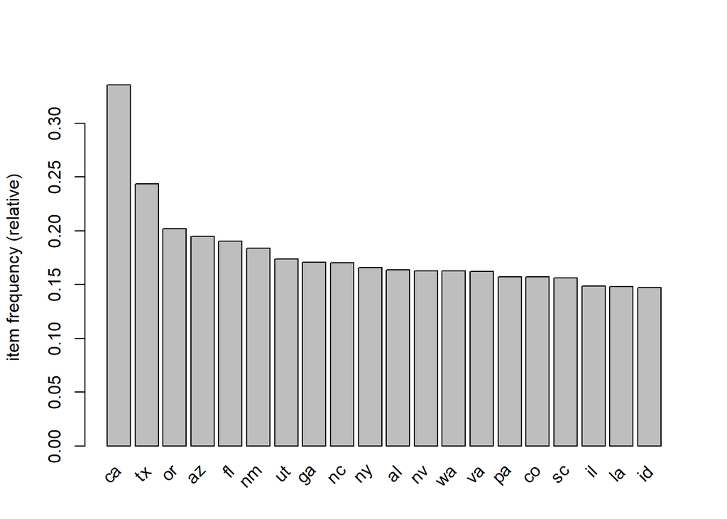

```r
itemFrequencyPlot(plant_data,topN=20)
```

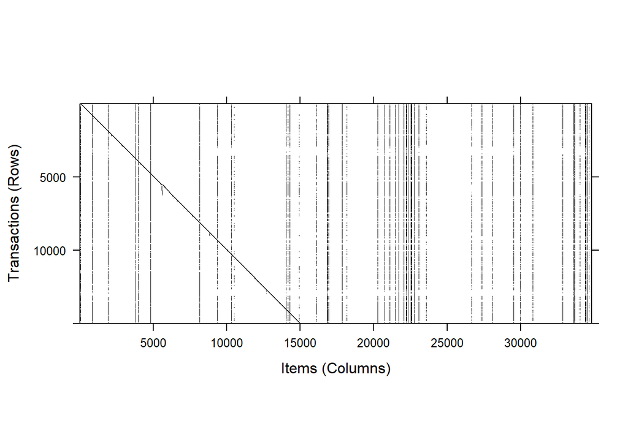

```r
#Observing the image of the transaction data with and without sampling
image(plant_data[1:15000])
```

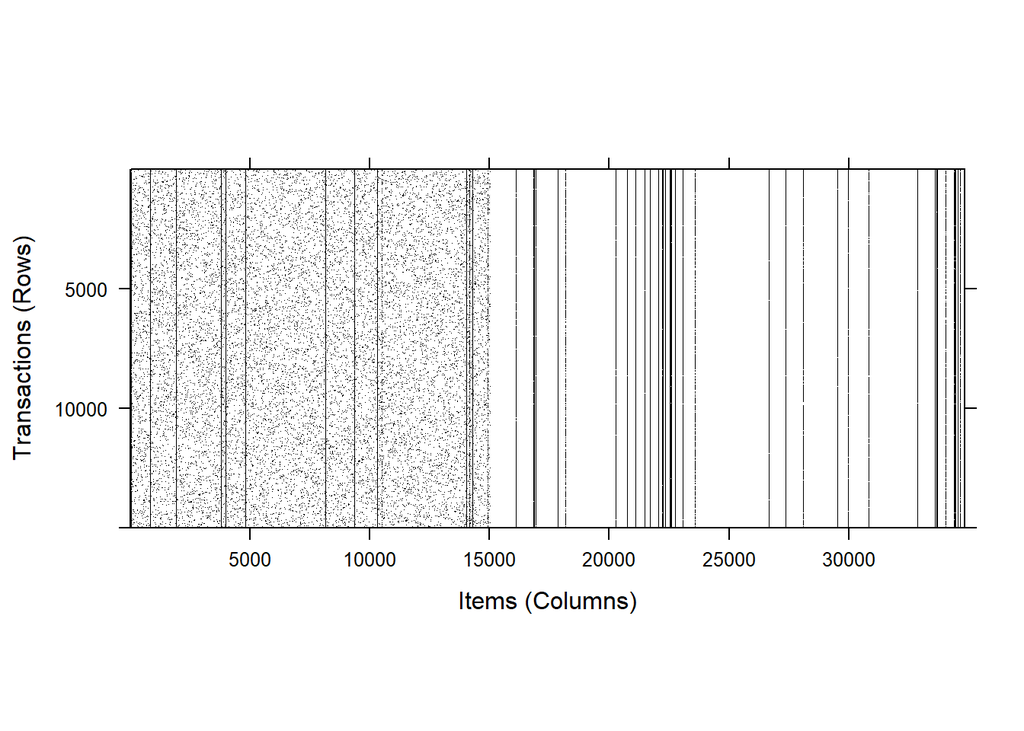

```r
image(sample(plant_data[1:15000]))
```

3. Use association rules to segment the data similar to what was done in Hämäläinen, W., & Nykänen, M. (2008, December). Efficient discovery of statistically significant association rules. In Data Mining, 2008. ICDM’08. Eighth IEEE International Conference on (pp. 203-212). IEEE.
- Using apriori function to build association rules for plants dataset
- Improving the model by adjusting the support and confidence
- Using Inspect and summary, we can observe the output

```r
#using apriori function to build rules
default_rules <- apriori(plant_data)
```

```
## Apriori
##
## Parameter specification:
##  confidence minval smax arem  aval originalSupport maxtime support minlen
##         0.8    0.1    1 none FALSE            TRUE       5     0.1      1
##  maxlen target  ext
##      10  rules TRUE
##
## Algorithmic control:
##  filter tree heap memopt load sort verbose
##     0.1 TRUE TRUE  FALSE TRUE    2    TRUE
##
## Absolute minimum support count: 3478
##
## set item appearances ...[0 item(s)] done [0.00s].
## set transactions ...[34851 item(s), 34781 transaction(s)] done [0.13s].
## sorting and recoding items ... [49 item(s)] done [0.01s].
## creating transaction tree ... done [0.01s].
## checking subsets of size 1 2 3 4 5 done [0.03s].
## writing ... [506 rule(s)] done [0.00s].
## creating S4 object  ... done [0.00s].
```

```r
summary(default_rules)
```

```
## set of 506 rules
##
## rule length distribution (lhs + rhs):sizes
##   2   3   4   5
##  89 307 100  10
##
##    Min. 1st Qu.  Median    Mean 3rd Qu.    Max.
##   2.000   3.000   3.000   3.061   3.000   5.000
##
## summary of quality measures:
##     support         confidence        coverage           lift
##  Min.   :0.1001   Min.   :0.8001   Min.   :0.1015   Min.   :2.470
##  1st Qu.:0.1015   1st Qu.:0.8582   1st Qu.:0.1110   1st Qu.:5.449
##  Median :0.1043   Median :0.8980   Median :0.1175   Median :5.793
##  Mean   :0.1071   Mean   :0.8969   Mean   :0.1200   Mean   :5.767
##  3rd Qu.:0.1100   3rd Qu.:0.9414   3rd Qu.:0.1247   3rd Qu.:6.092
##  Max.   :0.1426   Max.   :0.9893   Max.   :0.1708   Max.   :7.424
##      count
##  Min.   :3480
##  1st Qu.:3532
##  Median :3626
##  Mean   :3726
##  3rd Qu.:3825
##  Max.   :4959
##
## mining info:
##        data ntransactions support confidence
##  plant_data         34781     0.1        0.8
```

```r
inspect(default_rules[1:5])
```

```
##     lhs     rhs  support   confidence coverage  lift     count
## [1] {nv} => {ca} 0.1351600 0.8291005  0.1630200 2.469762 4701
## [2] {wy} => {mt} 0.1098013 0.8108280  0.1354188 5.875294 3819
## [3] {wy} => {co} 0.1104339 0.8154989  0.1354188 5.190095 3841
## [4] {mt} => {id} 0.1123027 0.8137500  0.1380064 5.518237 3906
## [5] {id} => {or} 0.1207268 0.8186781  0.1474656 4.051571 4199
```

```r
#Improving rules by changing default parameters
new_rules <- apriori(plant_data, parameter = list (support = 0.001, confidence = 0.75))
```

```
## Apriori
##
## Parameter specification:
##  confidence minval smax arem  aval originalSupport maxtime support minlen
##        0.75    0.1    1 none FALSE            TRUE       5   0.001      1
##  maxlen target  ext
##      10  rules TRUE
##
## Algorithmic control:
##  filter tree heap memopt load sort verbose
##     0.1 TRUE TRUE  FALSE TRUE    2    TRUE
##
## Absolute minimum support count: 34
##
## set item appearances ...[0 item(s)] done [0.00s].
## set transactions ...[34851 item(s), 34781 transaction(s)] done [0.12s].
## sorting and recoding items ... [70 item(s)] done [0.01s].
## creating transaction tree ... done [0.01s].
## checking subsets of size 1 2 3 4 5
```

```
##  done [17.55s].
## writing ... [43995074 rule(s)] done [5.80s].
## creating S4 object  ... done [14.19s].
```

```r
summary(new_rules)
```

```
## set of 43995074 rules
##
## rule length distribution (lhs + rhs):sizes
##        2        3        4        5
##      469    68831  2201628 41724146
##
##    Min. 1st Qu.  Median    Mean 3rd Qu.    Max.
##   2.000   5.000   5.000   4.947   5.000   5.000
##
## summary of quality measures:
##     support           confidence        coverage             lift
##  Min.   :0.001006   Min.   :0.7500   Min.   :0.001006   Min.   : 2.234
##  1st Qu.:0.007360   1st Qu.:0.8729   1st Qu.:0.007935   1st Qu.: 6.013
##  Median :0.015411   Median :0.9399   Median :0.016791   Median : 7.018
##  Mean   :0.017252   Mean   :0.9202   Mean   :0.018989   Mean   : 7.515
##  3rd Qu.:0.024381   3rd Qu.:0.9788   3rd Qu.:0.027055   3rd Qu.: 8.652
##  Max.   :0.158765   Max.   :1.0000   Max.   :0.202064   Max.   :67.350
##      count
##  Min.   :  35
##  1st Qu.: 256
##  Median : 536
##  Mean   : 600
##  3rd Qu.: 848
##  Max.   :5522
##
## mining info:
##        data ntransactions support confidence
##  plant_data         34781   0.001       0.75
```

```r
inspect(new_rules[1:5])
```

```
##     lhs        rhs      support    confidence coverage   lift      count
## [1] {gl}    => {qc}     0.01236307 0.7664884  0.01612950  6.240457 430
## [2] {dengl} => {lb}     0.01204681 0.8747390  0.01377189 21.231192 419
## [3] {dengl} => {fraspm} 0.01377189 1.0000000  0.01377189 28.744628 479
## [4] {dengl} => {yt}     0.01049424 0.7620042  0.01377189 12.620603 365
## [5] {dengl} => {nt}     0.01081050 0.7849687  0.01377189 13.489128 376
```

4. Are there clusters in the data? Can plants be segmented into groups? Build a k-means clustering model to investigate.
- First I converted the transactions to separate items and transaction ID by importing it again
- Later I stored this data in a dataframe in matrix format
- Using kmeans function, I built clusters of the data by using k = 10 for creating 10 clusters
- Using size and centers we can observe the center and size of the cluster
- Using plotCluster function I visualize the clusters
- For this problem, I referred a few links I have added them in this chunk

```r
#Importing the data as separate columns
plants <- read.transactions("C:\\Users\\harsh\\Desktop\\Introduction to Machine learning and Data Mining\\Practicum-3\\plants.data", sep = ",", cols = 1)

#Observing the new data
summary(plants)
```

```
## transactions as itemMatrix in sparse format with
##  34781 rows (elements/itemsets/transactions) and
##  70 columns (items) and a density of 0.1240883
##
## most frequent items:
##      ca      tx      or      az      fl (Other)
##   11676    8483    7028    6778    6621  261528
##
## element (itemset/transaction) length distribution:
## sizes
##     1     2     3     4     5     6     7     8     9    10    11    12    13
## 11566  4874  2954  2107  1366  1094   859   744   655   562   503   421   421
##    14    15    16    17    18    19    20    21    22    23    24    25    26
##   333   322   284   252   241   249   207   200   212   198   195   155   152
##    27    28    29    30    31    32    33    34    35    36    37    38    39
##   190   179   159   146   140   146   148   147   119   123   110   124   118
##    40    41    42    43    44    45    46    47    48    49    50    51    52
##   114    83    85   102    90    90    75    64    89    63    60    64    68
##    53    54    55    56    57    58    59    60    61    62    63    64    65
##    56    54    51    59    47    45    39    59    52    43    39    43    47
##    66    67    68    69
##    60    35    26     4
##
##    Min. 1st Qu.  Median    Mean 3rd Qu.    Max.
##   1.000   1.000   3.000   8.686   9.000  69.000
##
## includes extended item information - examples:
##   labels
## 1     ab
## 2     ak
## 3     al
##
## includes extended transaction information - examples:
##          transactionID
## 1               abelia
## 2 abelia x grandiflora
## 3          abelmoschus
```

```r
#Converting the data to matrix format and as integer datatype
plants_matrix <- as.data.frame(as(plants,"matrix"))
plants_matrix[,1:70] <- lapply(plants_matrix[,1:70],as.integer)

#Verifying the data
str(plants_matrix)
```

```
## 'data.frame':    34781 obs. of  70 variables:
##  $ ab    : int  0 0 0 0 0 1 0 0 1 1 ...
##  $ ak    : int  0 0 0 0 0 1 0 1 0 0 ...
##  $ al    : int  0 0 0 0 0 0 0 0 0 0 ...
##  $ ar    : int  0 0 0 0 0 0 0 0 0 0 ...
##  $ az    : int  0 0 0 0 0 1 0 0 0 0 ...
##  $ bc    : int  0 0 0 0 0 1 0 1 0 0 ...
##  $ ca    : int  0 0 0 0 0 1 0 1 0 0 ...
##  $ co    : int  0 0 0 0 0 1 0 0 0 0 ...
##  $ ct    : int  0 0 1 1 0 1 0 0 1 1 ...
##  $ dc    : int  0 0 1 1 0 0 0 0 0 0 ...
##  $ de    : int  0 0 0 0 0 0 0 0 0 0 ...
##  $ dengl : int  0 0 0 0 0 0 0 0 0 0 ...
##  $ fl    : int  1 1 1 1 0 0 0 0 0 0 ...
##  $ fraspm: int  0 0 0 0 0 1 0 0 1 1 ...
```

[output cut: 56 more lines]

```r
#Creating the clusters using kmeans function
clusters <- kmeans(plants_matrix,10)
clusters$size
```

```
##  [1]  1298 15255  1829  2966  2573  3200  3712  1819  1244   885
```

```r
clusters$centers
```

```
##            ab           ak          al          ar         az           bc
## 1  0.79583975 0.5577812018 0.747303544 0.785824345 0.78659476 0.9060092450
## 2  0.01514258 0.0499508358 0.022287775 0.023402163 0.08266142 0.0294985251
## 3  0.51503554 0.1946418808 0.008201203 0.039365774 0.52214325 0.5855658830
## 4  0.04888739 0.0839514498 0.005731625 0.004720162 0.07956844 0.2784895482
## 5  0.00272056 0.0015546055 0.890011660 0.443839876 0.09871745 0.0163233579
## 6  0.00500000 0.0015625000 0.013750000 0.045000000 0.74906250 0.0025000000
## 7  0.00000000 0.0002693966 0.025862069 0.001885776 0.01724138 0.0002693966
## 8  0.03298516 0.0126443101 0.929631666 0.936778450 0.15777900 0.0923584387
## 9  0.12700965 0.1093247588 0.180064309 0.088424437 0.02331190 0.2556270096
## 10 0.92203390 0.8011299435 0.016949153 0.045197740 0.30960452 0.9209039548
##            ca         co          ct          dc           de        dengl
## 1  0.89060092 0.92295840 0.973035439 0.769645609 0.8405238829 0.2003081664
## 2  0.31642085 0.02707309 0.014749263 0.005244182 0.0057030482 0.0007866273
## 3  0.68999453 0.83378896 0.012575178 0.006560962 0.0071077091 0.0000000000
```

[output cut: 117 more lines]

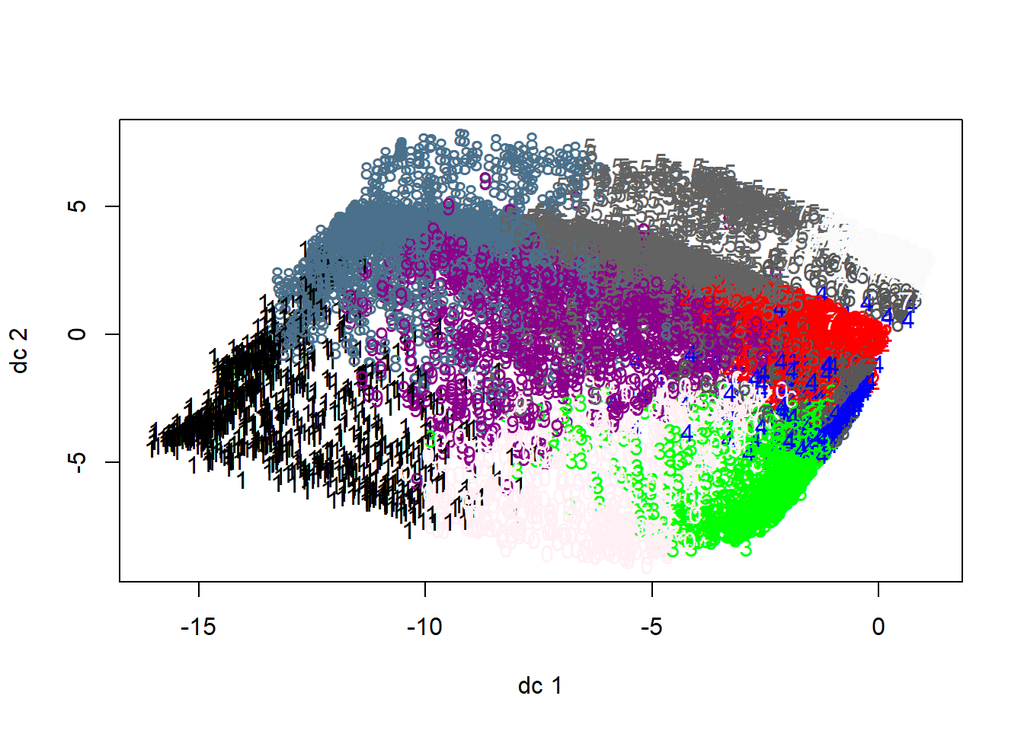

```r
#Visualizing the clusters
plotcluster(plants_matrix,clusters$cluster)
```

Reference: https://stats.stackexchange.com/questions/31083/how-to-produce-a-pretty-plot-of-the-results-of-k-means-cluster-analysis https://stackoverflow.com/questions/41972270/how-to-convert-object-of-transaction-to-dataframe-in-r